# Strategic Business Ventures & Opportunities

Shantanu Godbole

October 20, 2018

We are excited to bring you an exciting development and new business opportunity that we believe would help Anheuser-Busch InBev employ rapid expansion, without disruption of current production. In 2017, Bud Light (#1) and Budweiser (#3) remained in the Top 3 of Best Selling Beer in USA, yet they (along with many others) saw a decline in market share. Millennials are drinking wine over beer. At the same time, the growing Hispanic population is driving the increase in demand for Mexican brand beers (Corona and Modelo). In addition, the growingcraft beer segment is maturing and starting to slow down. This puts Anheuser-Busch in a unique situation which they may be able to capitalize on in order to drive shareholder wealth! [source](https://www.usatoday.com/story/money/food/2018/07/04/top-selling-beers-in-america-budweiser-coors-heineken/36440871/)

## **Breweries Across America**

As you can clearly see below, 10 states are home to over 50% of the breweries across the USA. In fact, Fort Collins, CO is home to a brewery from Anheuser-Busch! Yet, it is not the large brewries that set CO apart. Colorado’s craft beer scene is what is driving its brewery numbers high! [source](http://www.cobizmag.com/Trends/Why-Colorado-reigns-as-the-Napa-Valley-of-beer/)

| State | Num of Breweries | Region |
| --- | --- | --- |
| CO | 47 | West |
| CA | 39 | West |
| OR | 29 | West |
| WA | 23 | West |
| AZ | 11 | West |
| MT | 9 | West |
| AK | 7 | West |
| ID | 5 | West |
| HI | 4 | West |
| NM | 4 | West |
| UT | 4 | West |
| WY | 4 | West |
| NV | 2 | West |

| State | Num of Breweries | Region |
| --- | --- | --- |
| PA | 25 | Northeast |
| MA | 23 | Northeast |
| NY | 16 | Northeast |
| VT | 10 | Northeast |
| ME | 9 | Northeast |
| CT | 8 | Northeast |
| RI | 5 | Northeast |
| NH | 3 | Northeast |
| NJ | 3 | Northeast |

| State | Num of Breweries | Region |
| --- | --- | --- |
| TX | 28 | South |
| NC | 19 | South |
| VA | 16 | South |
| FL | 15 | South |
| GA | 7 | South |
| MD | 7 | South |
| OK | 6 | South |
| LA | 5 | South |
| KY | 4 | South |
| SC | 4 | South |
| AL | 3 | South |
| TN | 3 | South |
| AR | 2 | South |
| DE | 2 | South |
| MS | 2 | South |
| WV | 1 | South |

| State | Num of Breweries | Region |
| --- | --- | --- |
| MI | 32 | Midwest |
| IN | 22 | Midwest |
| WI | 20 | Midwest |
| IL | 18 | Midwest |
| OH | 15 | Midwest |
| MN | 12 | Midwest |
| MO | 9 | Midwest |
| IA | 5 | Midwest |
| NE | 5 | Midwest |
| KS | 3 | Midwest |
| ND | 1 | Midwest |
| SD | 1 | Midwest |

When we look at the numbers, we begin to see that 2410 beers are produced by these 558 brewries. Most of the beers are produced in Texas, California, Colorado and Pennsylvania. The charts below will give us a quick picture of the data and variables that we have in our dataset.

| Brewery_id | Beer Name | Beer_ID | ABV | IBU | Style | Ounces | Brewery Name | City | State |
| --- | --- | --- | --- | --- | --- | --- | --- | --- | --- |
| 1 | Get Together | 2692 | 0.045 | 50 | American IPA | 16 | NorthGate Brewing | Minneapolis | MN |
| 1 | Maggie’s Leap | 2691 | 0.049 | 26 | Milk / Sweet Stout | 16 | NorthGate Brewing | Minneapolis | MN |
| 1 | Wall’s End | 2690 | 0.048 | 19 | English Brown Ale | 16 | NorthGate Brewing | Minneapolis | MN |
| 1 | Pumpion | 2689 | 0.060 | 38 | Pumpkin Ale | 16 | NorthGate Brewing | Minneapolis | MN |
| 1 | Stronghold | 2688 | 0.060 | 25 | American Porter | 16 | NorthGate Brewing | Minneapolis | MN |
| 1 | Parapet ESB | 2687 | 0.056 | 47 | Extra Special / Strong Bitter (ESB) | 16 | NorthGate Brewing | Minneapolis | MN |

|  | Brewery_id | Beer Name | Beer_ID | ABV | IBU | Style | Ounces | Brewery Name | City | State |
| --- | --- | --- | --- | --- | --- | --- | --- | --- | --- | --- |
| 2405 | 556 | Pilsner Ukiah | 98 | 0.055 | NA | German Pilsener | 12 | Ukiah Brewing Company | Ukiah | CA |
| 2406 | 557 | Heinnieweisse Weissebier | 52 | 0.049 | NA | Hefeweizen | 12 | Butternuts Beer and Ale | Garrattsville | NY |
| 2407 | 557 | Snapperhead IPA | 51 | 0.068 | NA | American IPA | 12 | Butternuts Beer and Ale | Garrattsville | NY |
| 2408 | 557 | Moo Thunder Stout | 50 | 0.049 | NA | Milk / Sweet Stout | 12 | Butternuts Beer and Ale | Garrattsville | NY |
| 2409 | 557 | Porkslap Pale Ale | 49 | 0.043 | NA | American Pale Ale (APA) | 12 | Butternuts Beer and Ale | Garrattsville | NY |
| 2410 | 558 | Urban Wilderness Pale Ale | 30 | 0.049 | NA | English Pale Ale | 12 | Sleeping Lady Brewing Company | Anchorage | AK |

We can see that out of those 2410 beers, over 1000 were missing an International Bitterness Unit (IBU). With how fast the craft beer industry turns over new beers, it is no surprise that we would have nearly half of the data set missing an IBU score. With respect to Alcohol By Volume (ABV), only 62 beers did not contain entries. We will have to be cognizant of the missing values. Nonetheless, we are still able to obtain significant data from the remaining records.

|  | na_count |
| --- | --- |
| Brewery_id | 0 |
| Beer Name | 0 |
| Beer_ID | 0 |
| ABV | 62 |
| IBU | 1005 |
| Style | 0 |
| Ounces | 0 |
| Brewery Name | 0 |
| City | 0 |
| State | 0 |

## **Median ABV and IBU Across America**

While the popular Bud Light an Budweiser are in the moderate ABV and IBU range, we can see that the median ABV and IBU across the country are higher than the top selling beer. We get a quick overview of where the brewries are outputting beers. Since microbrewries don’t have the same distribution network as major companies, they tend to talor to local tastes, which gives us a very strong indicator of what that state’s population is producing.

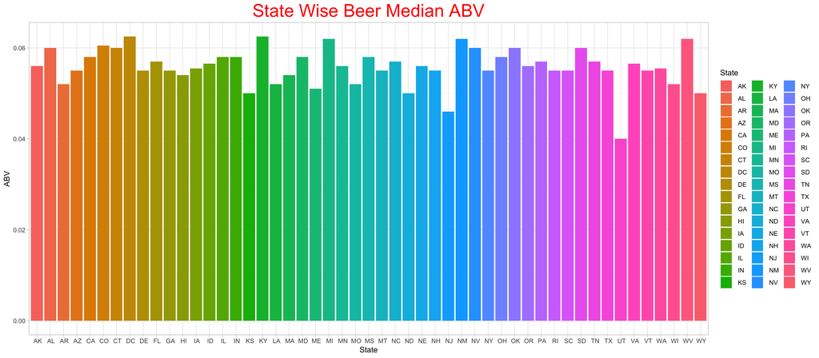

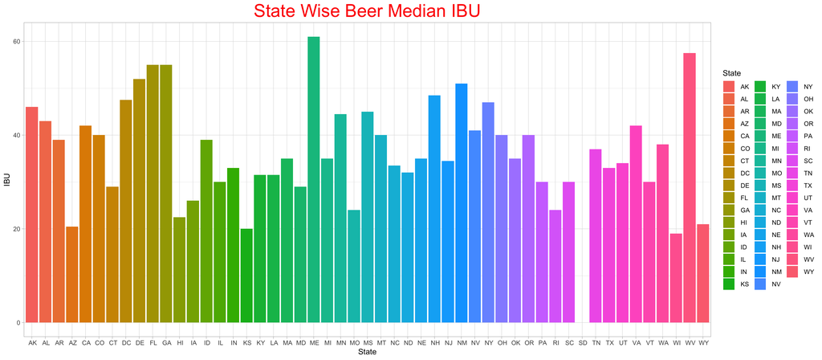

Looking closer into the data, we get to see CO, the state with the most brewries, is producing the higest ABV at .128. While OR is clearly experimenting with a high IBU beer with a score of 138 (nearly double tht of Bud Light)!

|  | ABV | State |
| --- | --- | --- |
| 375 | 0.128 | CO |

|  | IBU | State |
| --- | --- | --- |
| 1857 | 138 | OR |

## **Alcohol By Volume: A Closer Look**

We see that out of 2410 beers, the least alcoholic is 0.1% alcohol, while the most alcoholic is 12.8% alcohol. Yet, we can also identify that 50% of the ABV for the beers range between 5% and 6.7%. With the half of the beers having an ABV level within1.7% of each other, it appears the customer has decided that is the ‘sweet spot’ for their alcohol tolerance.

```
##    Min. 1st Qu.  Median    Mean 3rd Qu.    Max.    NA's
## 0.00100 0.05000 0.05600 0.05977 0.06700 0.12800      62
```

## **What does it all mean?**

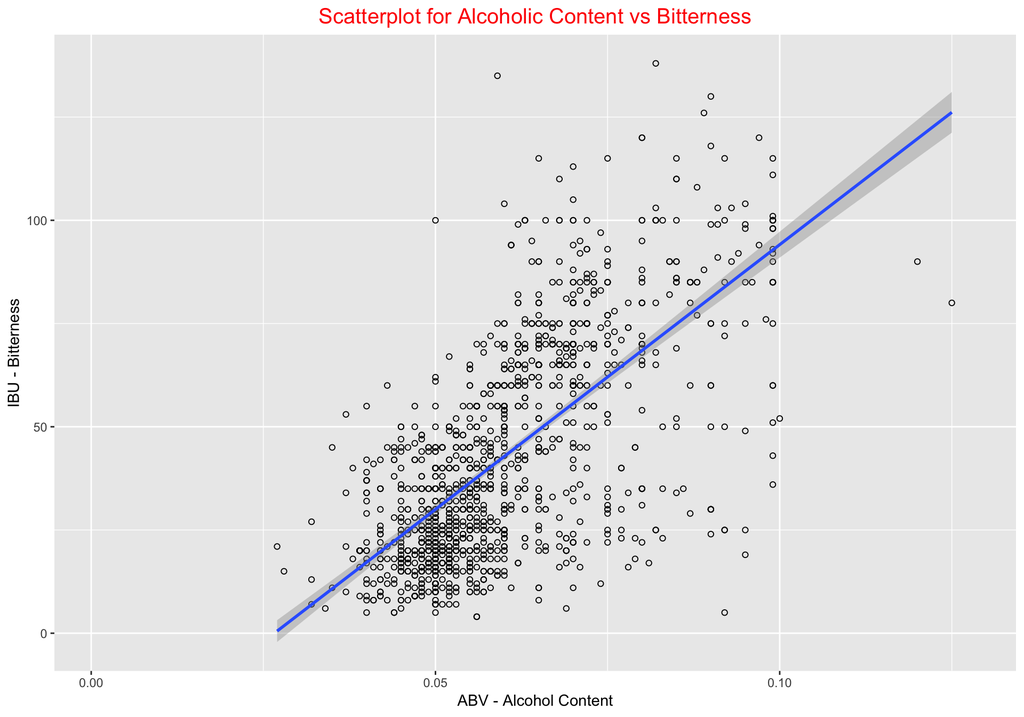